# In-Class Session 9 (Python): Difference-in-Differences and Staggered Adoption

Author

Econometrics I

This is the Python twin of `inclass_session9.Rmd`: the same simulations and problems, written with `numpy`, `pandas` and `pyfixest`. Everything is simulated, so you always know the right answer.

Setup (one time): `uv pip install pyfixest` (or `pip install pyfixest`).

```python
import numpy as np
import pandas as pd
import pyfixest as pf

rng = np.random.default_rng(9)
```

# Part 1: The two-by-two (Lecture 9a)

## Reproduce: a SOX-404-style mandate

Firms with public float of at least $75M (“accelerated filers”) must comply from fiscal 2004; smaller firms are exempt. The outcome is log audit fees. The true effect is $+0.35$ in 2004, decaying to $+0.20$ by 2007. Larger firms are on a steeper audit-fee trend (`kappa` per year per standard deviation of size).

```python
years = np.arange(2000, 2008)
tau_sox = {2004: 0.35, 2005: 0.28, 2006: 0.22, 2007: 0.20}

def sim_sox(N=2000, kappa=0.06, sd_eps=0.12):
    lfloat = rng.normal(np.log(75), 1.2, N)
    size = (lfloat - lfloat.mean()) / lfloat.std(ddof=1)
    acc = (lfloat >= np.log(75)).astype(int)
    alpha = 11 + 0.5 * size + rng.normal(0, 0.4, N)
    gam = np.cumsum(np.r_[0, rng.normal(0.03, 0.02, len(years) - 1)])
    d = pd.DataFrame({"firm": np.repeat(np.arange(N), len(years)), "year": np.tile(years, N)})
    d["size"] = size[d.firm]; d["acc"] = acc[d.firm]
    d["post"] = (d.year >= 2004).astype(int)
    d["tau"] = np.where((d.acc == 1) & (d.post == 1), d.year.map(tau_sox).fillna(0), 0.0)
    d["y"] = (alpha[d.firm] + gam[d.year - 2000] + kappa * d["size"] * (d.year - 2003)
              + d.tau + rng.normal(0, sd_eps, len(d)))
    d["D"] = d.acc * d.post
    return d

sox = sim_sox()
```

The four routes to the $2\times2$ (fiscal 2003 vs. 2004):

```python
two = sox[sox.year.isin([2003, 2004])]
cm = two.groupby(["acc", "year"]).y.mean()
dd_means = (cm[1, 2004] - cm[1, 2003]) - (cm[0, 2004] - cm[0, 2003])

w = two.pivot(index=["firm", "acc", "size"], columns="year", values="y").reset_index()
w["dy"] = w[2004] - w[2003]
fit_fd = pf.feols("dy ~ acc", data=w, vcov="hetero")
fit_int = pf.feols("y ~ acc + post + acc:post", data=two, vcov={"CRV1": "firm"})
fit_twfe = pf.feols("y ~ D | firm + year", data=two, vcov={"CRV1": "firm"})
pd.Series({"means": dd_means, "fd": fit_fd.coef()["acc"],
           "interaction": fit_int.coef()["acc:post"], "twfe": fit_twfe.coef()["D"]})
```

```
means          0.433099
fd             0.433099
interaction    0.433099
twfe           0.433099
dtype: float64
```

They agree, and they all miss the truth of 0.35. Conditioning on size:

```python
pf.feols("dy ~ acc + size", data=w, vcov="hetero").tidy().loc["acc"]
```

```
Estimate       0.327060
Std. Error     0.013158
t value       24.856312
Pr(>|t|)       0.000000
2.5%           0.301255
97.5%          0.352865
Name: acc, dtype: float64
```

The event study, with and without size-specific year effects:

```python
fit_es = pf.feols("y ~ i(year, acc, ref=2003) | firm + year", data=sox, vcov={"CRV1": "firm"})
fit_es_c = pf.feols("y ~ i(year, acc, ref=2003) + i(year, size, ref=2003) | firm + year",
                    data=sox, vcov={"CRV1": "firm"})
pf.etable([fit_es, fit_es_c], keep="acc")
```

|  | y (1) | y (2) |
| --- | --- | --- |
| coef |  |  |
| year × × 2000 × acc | -0.301*** (0.009) | -0.009 (0.013) |
| year × × 2001 × acc | -0.192*** (0.008) | -0.007 (0.013) |
| year × × 2002 × acc | -0.103*** (0.008) | -0.022 (0.013) |
| year × × 2004 × acc | 0.433*** (0.008) | 0.327*** (0.013) |
| year × × 2005 × acc | 0.444*** (0.008) | 0.241*** (0.013) |
| year × × 2006 × acc | 0.495*** (0.009) | 0.189*** (0.013) |
| year × × 2007 × acc | 0.575*** (0.010) | 0.186*** (0.013) |
| fe |  |  |
| year | x | x |
| firm | x | x |
| stats |  |  |
| Observations | 16,000 | 16,000 |
| R<sup>2</sup> | 0.966 | 0.978 |

Significance levels: * p < 0.05, ** p < 0.01, *** p < 0.001. Format of coefficient cell: Coefficient (Std. Error)

### Problem 1

Re-simulate with `kappa=0` (no size trend). How far is the plain DiD from 0.35 now? Does adding size still change the estimate? What happens to its standard error, and why? (Hint: how correlated are `acc` and `size`?)

```python
# your code here
```

### Problem 2

Replace the linear size control with size-decile fixed effects (`w["dec"] = pd.qcut(w["size"], 10, labels=False)`, then `pf.feols("dy ~ acc | dec", data=w)`). Which deciles contain both accelerated and exempt firms? What happens to the estimate and its standard error? Connect your answer to “conditioning needs overlap” and to regression discontinuity.

```python
# your code here
```

## Reproduce: placebo laws (Bertrand, Duflo and Mullainathan 2004)

A state-by-year panel with AR(1) errors. Half the states “pass a law” in a random year between 6 and 15. The law does nothing. How often does a 5% test reject?

```python
def bdm_once(S=50, T=20, rho=0.8):
    e = np.zeros((S, T)); e[:, 0] = rng.normal(0, 1 / np.sqrt(1 - rho**2), S)
    for t in range(1, T):
        e[:, t] = rho * e[:, t - 1] + rng.normal(size=S)
    start = np.full(S, np.inf)
    tr = rng.choice(S, S // 2, replace=False)
    start[tr] = rng.integers(6, 16, len(tr))
    d = pd.DataFrame({"state": np.repeat(np.arange(S), T), "t": np.tile(np.arange(1, T + 1), S)})
    d["y"] = rng.normal(size=S)[d.state] + 0.1 * d.t + e[d.state, d.t - 1]
    d["D"] = (d.t >= start[d.state]).astype(int)
    out = {}
    for name, v in {"iid": "iid", "hetero": "hetero", "cluster": {"CRV1": "state"}}.items():
        out[name] = pf.feols("y ~ D | state + t", data=d, vcov=v).pvalue()["D"] < 0.05
    return out

pd.DataFrame([bdm_once() for _ in range(200)]).mean()
```

```
iid        0.415
hetero     0.405
cluster    0.060
dtype: float64
```

### Problem 3

Vary `rho` (0, 0.5, 0.9) and the number of states `S` (6, 10, 50). Make a small table of rejection rates for clustered standard errors. Where does clustering stop working? Now give the law to only *one* state: what happens?

```python
# your code here
```

# Part 2: Staggered adoption (Lecture 9b)

## Reproduce: an algorithm rolled out city by city

300 cities, 20 months, four launch waves (months 6, 9, 12, 15) and a never-treated group, 60 cities each. The effect ramps in over eight months and is larger for earlier waves. Never-treated cities have cohort `g = 0` (the convention `pyfixest`’s DiD functions use).

```python
T_, waves = 20, [6, 9, 12, 15]

def sim_rollout(theta={6: 0.12, 9: 0.09, 12: 0.06, 15: 0.04}, ramp=8, n_per=60, groups=(6, 9, 12, 15, 0)):
    G = np.repeat(groups, n_per); N = len(G)
    d = pd.DataFrame({"id": np.repeat(np.arange(N), T_), "t": np.tile(np.arange(1, T_ + 1), N)})
    d["g"] = G[d.id]
    gam = np.cumsum(rng.normal(0.01, 0.02, T_))
    d["D"] = ((d.g > 0) & (d.t >= d.g)).astype(int)
    d["e"] = np.where(d.g > 0, d.t - d.g, -1000)
    d["tau"] = np.where(d.D == 1, d.g.map(theta).fillna(0) * np.minimum(d.e + 1, ramp) / ramp, 0.0)
    d["y"] = rng.normal(0, 0.3, N)[d.id] + gam[d.t - 1] + d.tau + rng.normal(0, 0.05, len(d))
    return d

d = sim_rollout()
att_true = d.loc[d.D == 1, "tau"].mean()
att_true
```

```
np.float64(0.06142857142857142)
```

Static two-way FE, and the weights it puts on each treated city-month. In a balanced panel the residualized treatment is $\tilde D_{it} = D_{it} - \bar D_{i\cdot} - \bar D_{\cdot t} + \bar D$:

```python
fit_static = pf.feols("y ~ D | id + t", data=d, vcov={"CRV1": "id"})
d["Dt"] = d.D - d.groupby("id").D.transform("mean") - d.groupby("t").D.transform("mean") + d.D.mean()
tr = d.D == 1
d.loc[tr, "w"] = d.loc[tr, "Dt"] / d.loc[tr, "Dt"].sum()
pd.Series({"twfe": fit_static.coef()["D"], "truth": att_true,
           "share_negative_rows": (d.loc[tr, "w"] < 0).mean(),
           "estimand_from_weights": (d.loc[tr, "w"] * d.loc[tr, "tau"]).sum()})
```

```
twfe                     0.027043
truth                    0.061429
share_negative_rows      0.142857
estimand_from_weights    0.026919
dtype: float64
```

## Reproduce: three clean estimators

Callaway and Sant’Anna by hand: each $\text{ATT}(g,t)$ is a $2\times2$ against a clean comparison group, relative to month $g-1$, averaged with cohort-size weights.

```python
def cs_att(d, control="never"):
    Y = d.pivot(index="id", columns="t", values="y"); G = d.groupby("id").g.first()
    rows = []
    for g in waves:
        ig = G.index[G == g]
        for t in range(g, T_ + 1):
            if control == "never":
                ic = G.index[G == 0]
            else:
                ic = G.index[((G > t) | (G == 0)) & (G != g)]
            if len(ic) == 0:
                continue
            att = (Y.loc[ig, t] - Y.loc[ig, g - 1]).mean() - (Y.loc[ic, t] - Y.loc[ic, g - 1]).mean()
            rows.append((g, t, len(ig), att))
    a = pd.DataFrame(rows, columns=["g", "t", "n", "att"])
    return np.average(a.att, weights=a.n)

pd.Series({"cs_never": cs_att(d, "never"), "cs_notyet": cs_att(d, "notyet"), "truth": att_true})
```

```
cs_never     0.065098
cs_notyet    0.065789
truth        0.061429
dtype: float64
```

Imputation, as Gardner’s two-stage DiD: stage one fits city and month effects on untreated observations; stage two regresses the residualized outcome on treatment.

```python
fit_did2s = pf.did2s(d, yname="y", first_stage="~ 0 | id + t", second_stage="~ D",
                     treatment="D", cluster="id")
fit_did2s.tidy()
```

| Coefficient | Estimate | Std. Error | t value | Pr(>\|t\|) | 2.5% | 97.5% |
| --- | --- | --- | --- | --- | --- | --- |
| D | 0.061494 | 0.003056 | 20.124563 | 0.0 | 0.055504 | 0.067484 |

The same estimator as an event study, plotted:

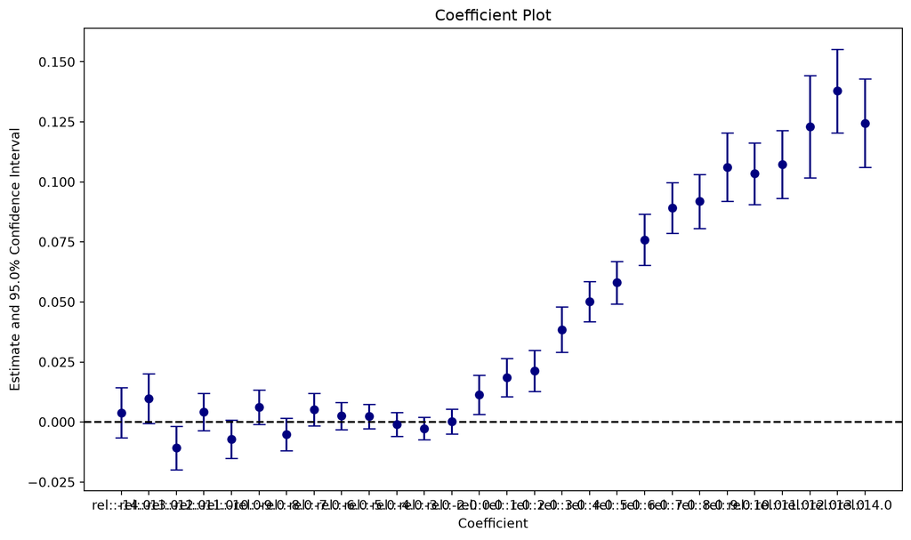

```python
d["rel"] = np.where(d.g > 0, d.t - d.g, -1.0).astype(float)
fit_es2s = pf.did2s(d, yname="y", first_stage="~ 0 | id + t", second_stage="~ i(rel, ref=-1.0)",
                    treatment="D", cluster="id")
fit_es2s.iplot(coord_flip=False)
```

### Problem 4

Re-simulate with a constant effect: `sim_rollout(theta={6: 0.06, 9: 0.06, 12: 0.06, 15: 0.06}, ramp=1)`. Re-run static two-way FE and the clean estimators. Which ones change, and why? Are any weights still negative? Why doesn’t that matter now?

```python
# your code here
```

### Problem 5

Drop the never-treated cities (`d[d.g > 0]`). Run `cs_att()` with `control="notyet"` and explain which $\text{ATT}(g,t)$ cells are missing and why. What can you still estimate for wave 6, and what can’t you?

```python
# your code here
```